[figure not shown]

# Fractals - The Mandelbrot and Julia Sets

A demonstration of creating Mandelbrot and Julia set images using the Julia language.

## Mandelbrot Set

The [Mandelbrot set](https://en.wikipedia.org/wiki/Mandelbrot_set) is defined on the complex plane as follows:

A complex number $c$ is in the Mandelbrot set if, for all positive integers $n$, $|z_n| < 2$ where $z_0 = 0$ and $z_{n+1} = z_n^2 + c$.

I.e. with $f(z) = z^2 + c$ we evaluate $z_1=f(z_0),\ z_2 = f(z_1),\ z_3 = f(z_2),\ ...$ and test whether each $z_n$ is still inside the radius $2$ circle.

The colours of the pixels are then defined by how many iterations it takes that point to reach the "escape radius" of $2$. I.e. some escape quickly and are on one end of the colour scale, some do not escape at all (these are assumed to part of the Mandelbrot set) and are on the other end of the colour scale.

The function below is slightly modified from the main page of the [Julia language](http://julialang.org/) website where it's used as one of the performance benchmarks.

```julia
function mandel(c, maxiter=80)
    z = c  # 1st iteration with z_0 = 0
    for n = 1:maxiter
        abs(z) > 2 ? (return n) : z = z^2 + c
    end
    return maxiter
end;
```

### Packages

The Images package will be used to display the fractals.  
The Colors package enables us to flexibly specify palettes.  
The IndirectArrays package provides a convenient method to map to a colormap.

```julia
using Images, Colors, IndirectArrays
```

### A detour on colour maps

Let's explore some colour palettes for plotting. There are a number of predefined (and named) palettes (e.g. "grays", "reds").

```julia
colormap("reds", 50) # defaults to 100 distinct colours but can choose your own number (here 50)
```

[figure not shown]

You can define your own linearly changing maps in the different available [colour spaces](https://github.com/JuliaGraphics/ColorTypes.jl) (of which there are many).

```julia
linspace(RGB(1,1,1), RGB(0,0,0), 80)
```

[figure not shown]

```julia
linspace(HSV(0,1,1), HSV(330,1,1))
```

[figure not shown]

A bit more complicated (but demonstrates the flexibility) - this is the way the Winston package defines a "jet" colour map.

```julia
jet = RGB{Float64}[
    RGB(clamp(min(4x - 1.5, -4x + 4.5), 0.0, 1.0),
        clamp(min(4x - 0.5, -4x + 3.5), 0.0, 1.0),
        clamp(min(4x + 0.5, -4x + 2.5), 0.0, 1.0))
    for x in linspace(0.0, 1.0, 80)]
```

[figure not shown]

You can use the *sequential_palette* and *diverging_palette* functions which take as inputs the hue (in [HSV colour space](https://en.wikipedia.org/wiki/HSL_and_HSV)) of each colour as well as the number of discrete colours.

```julia
sequential_palette(12, 60) # 12 is the hue, 60 is the number of colours
```

[figure not shown]

```julia
diverging_palette(255, 86, 10) # 255 is the left hand side hue and 86 is the right hand side hue
```

[output not shown]

And you can combine different colour maps into a single map by concatenation. The diverging red-grey and blue-grey ones below work quite well for the fractals so we can name and save them.

```julia
RedGrey = [flipdim(sequential_palette(12, 40), 1); colormap("grays", 40)]
```

[figure not shown]

```julia
BlueGrey = [flipdim(colormap("blues", 40), 1); colormap("grays", 40)]
```

[figure not shown]

### Back to the fractals

First we need to create a canvas that we'll plot. Take the $2D$ complex plane and allocate to each point (or "pixel") the output of the function *mandel* i.e. the number of iterations, starting from that point in the plane, it takes to reach the "escape radius".

Comprehension syntax is a neat way to do this. The time taken for this calculation through an array is dependant on the number of pixels, the maximum number of iterations, and how quickly locations in the selected region "escape".

```julia
canvas = UInt8[mandel(complex(re, im)) for im in 1.25:-1e-3:-1.25, re in -2.25:1e-3:1.25];
```

Starting with a greyscale image:

[figure not shown]

```julia
IndirectArray(canvas, colormap("grays", 80))
```

The greyscale image looks nice and clean. But let's add colour which can show some of the patterns a little clearer.

[figure not shown]

```julia
IndirectArray(canvas, BlueGrey)
```

To control the canvas dimensions explicitly we'll define a function that takes as inputs the start (top left) and finish (bottom right) points as well as the width. The height is calculated to keep the real axis and imaginary axis on the same scale.

```julia
function create_ranges(start::Complex, finish::Complex, width::Int)
    incr = abs(finish.re - start.re) / (width - 1)
    reRange = start.re:incr:finish.re
    imRange = start.im:-incr:finish.im
    return reRange, imRange
end;
```

To zoom in, different regions can be chosen and viewed. The image below is from the "triple spiral valley" between the main bulb and the north bulb.

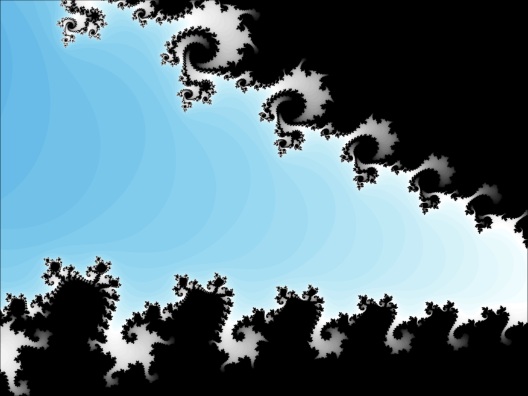

```julia
reRange, imRange = create_ranges(-0.210 + 0.675im, -0.170 + 0.645im, 3500)
canvas = UInt8[mandel(complex(re, im)) for im in imRange, re in reRange]
IndirectArray(canvas, BlueGrey)
```

### Julia Set

The Julia set is defined similarly to the Mandelbrot set with the difference that $c$ is now a fixed constant and the starting value of $z$ is now the pixel location. I.e.

A complex number $z_0$ is in the Julia set if, for all positive integers $n$, $|z_n| < 2$ where $z_{n+1} = z_n^2 + c$.

So each constant $c$ returns a different Julia set.

The function below follows the definition.

```julia
function julia(z, c, maxiter=80)
    for n = 1:maxiter
        abs(z) > 2 ? (return n) : z = z^2 + c
    end
    return maxiter
end;
```

Below are a few examples for different values of $c$.

$c = -0.4 + 0.6i$

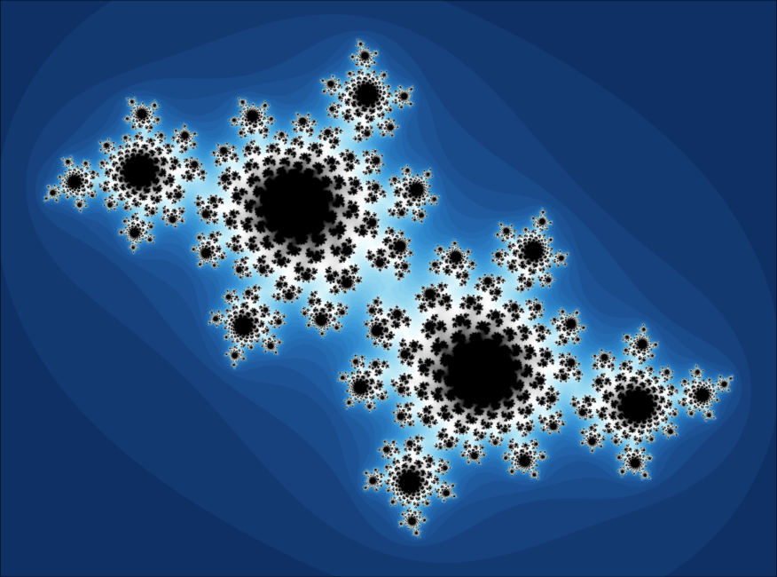

```julia
reRange, imRange = create_ranges(-1.55 + 1.15im, 1.55 - 1.15im, 3500)
canvas = UInt8[julia(complex(re, im), complex(-0.40, 0.60)) for im in imRange, re in reRange]
IndirectArray(canvas, BlueGrey)
```

$c = 0.285 + 0.01i$

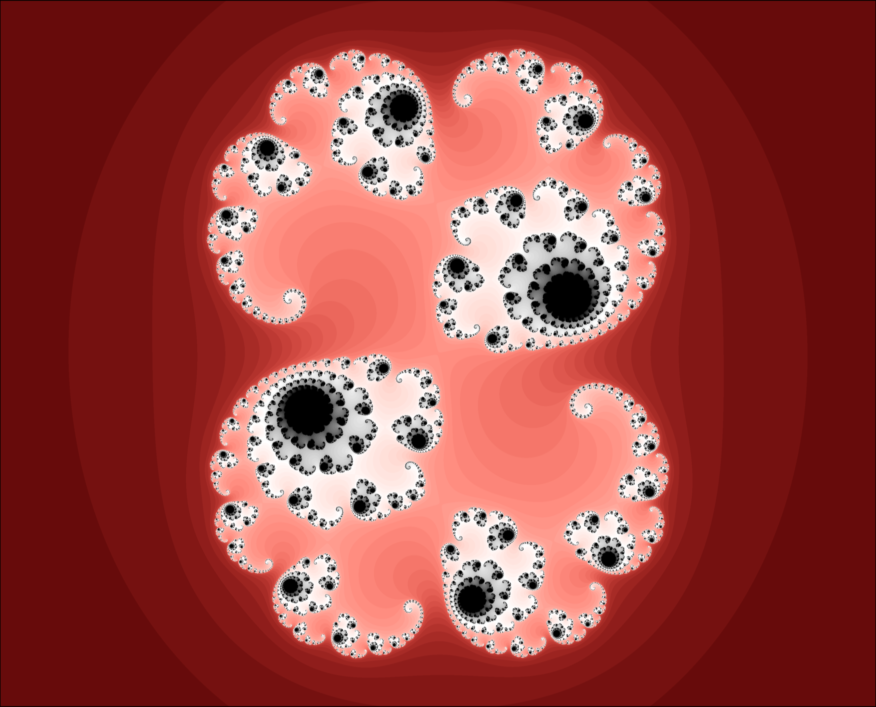

```julia
reRange, imRange = create_ranges(-1.55 + 1.25im, 1.55 - 1.25im, 3500)
canvas = UInt8[ julia(complex(re, im), complex(0.285, 0.010)) for im in imRange, re in reRange ]
IndirectArray(canvas, RedGrey)
```

### Animations

The Interact package enables the creation of animations in a relativeley straightforward way. These won't be interactable on the html page but you can create for yourself in Julia.

```julia
using Interact
```

We can vary the value of $c$ with "sliders". Using polar coordinates over the complex plane we could provide a fixed radius $r$ and just vary the angle $\theta$ or we can build sliders to vary both $r$ and $\theta$.

#### Fixed $r$, varying $\theta$

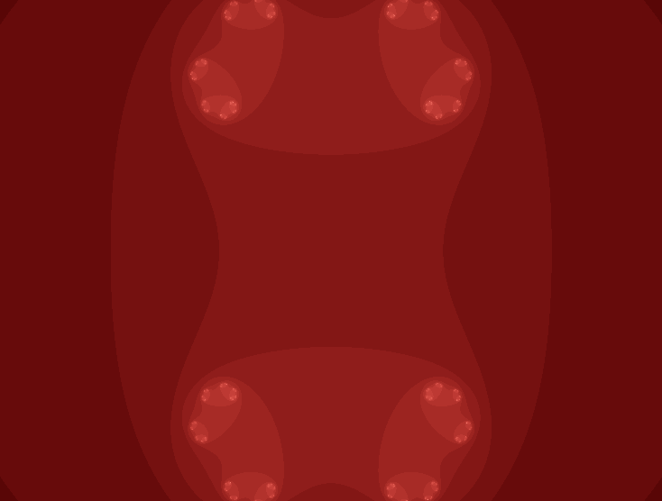

```julia
r = 0.7885
@manipulate for θ = slider(0:0.01:2π, value=0., label="θ")
    canvas = UInt8[julia(complex(re, im), complex(r*cos(θ), r*sin(θ))) for im=1.25:-4.5e-3:-1.25, re=-1.65:4.5e-3:1.65]
    IndirectArray(canvas, RedGrey)
end
```

#### Varying both $r$ and $\theta$

[figure not shown]

```julia
@manipulate for θ = slider(0:0.01:2π, value=0., label="θ"), r = slider(0:0.01:2, value=0., label="r")
    canvas = UInt8[julia(complex(re, im), complex(r*cos(θ), r*sin(θ))) for im=1.25:-4.5e-3:-1.25, re=-1.65:4.5e-3:1.65]
    IndirectArray(canvas, BlueGrey)
end
```